# PCIT-CoS-Waitlist RCT Paper 1: DPICS NTA, Controlling for ASD

Nancy Briggs

31 JAN 2021

### DPICS NTA Controlling for ASD

#### Descriptives

| asdcase | group | time | n | mean | sd | median | min | max |
| --- | --- | --- | --- | --- | --- | --- | --- | --- |
| 0 | 1 | 1 | 24 | 4.1536402 | 3.2851693 | 3.5923020 | 0.3745318 | 12.672811 |
| 0 | 1 | 2 | 18 | 0.9846973 | 1.0901764 | 0.5698052 | 0.0000000 | 3.140097 |
| 0 | 1 | 3 | 13 | 0.9321502 | 1.2065783 | 0.4255319 | 0.0000000 | 4.385965 |
| 0 | 2 | 1 | 26 | 4.0367004 | 3.2879053 | 3.4002490 | 0.0000000 | 12.716763 |
| 0 | 2 | 2 | 10 | 2.9815837 | 2.9948797 | 1.9999126 | 0.3552398 | 9.325397 |
| 0 | 2 | 3 | 5 | 3.1532309 | 3.4081637 | 1.4760148 | 0.7352941 | 8.809524 |
| 0 | 3 | 1 | 25 | 4.1440762 | 3.3311484 | 3.1128405 | 0.8333333 | 14.077670 |
| 0 | 3 | 2 | 22 | 1.8389630 | 1.7043396 | 1.6866826 | 0.0000000 | 8.113590 |
| 0 | 3 | 3 | 1 | 0.9074410 | NA | 0.9074410 | 0.9074410 | 0.907441 |
| 1 | 1 | 1 | 6 | 4.1394936 | 2.8012139 | 3.6849222 | 0.6060606 | 8.908046 |
| 1 | 1 | 2 | 4 | 1.8304019 | 2.4506441 | 0.9958292 | 0.0000000 | 5.329949 |
| 1 | 1 | 3 | 5 | 0.9267725 | 0.8019167 | 0.9036145 | 0.0000000 | 2.056962 |
| 1 | 2 | 1 | 3 | 5.4763973 | 3.1416654 | 6.6202091 | 1.9230769 | 7.885906 |
| 1 | 2 | 2 | 2 | 1.9230769 | 2.7196415 | 1.9230769 | 0.0000000 | 3.846154 |
| 1 | 2 | 3 | 0 | NaN | NA | NA | Inf | -Inf |
| 1 | 3 | 1 | 5 | 7.4585265 | 7.0856157 | 6.6450567 | 1.2048193 | 18.820225 |
| 1 | 3 | 2 | 4 | 4.8712184 | 3.0877663 | 4.0477996 | 2.1035599 | 9.285714 |
| 1 | 3 | 3 | 0 | NaN | NA | NA | Inf | -Inf |

Note that with the number of ASD cases, it is unlikely that a model with the group*time* ASD interaction will run at all.

[figure not shown]

#### Model & Results

```
## fixed-effect model matrix is rank deficient so dropping 1 column / coefficient
```

The model with asdcase*group*time does not converge. We will leave it out.

```r
result4<-glmer(cbind(nta, verbal-nta) ~ asdcase:group:time + (1 | id), data=p, family=binomial)
```

```
## fixed-effect model matrix is rank deficient so dropping 4 columns / coefficients
```

This is the ANOVA table for the model. p-values are likelihood ratio tests for adding the new term to the model just before. A p-value <0.05 indicates that adding that term results in better model fit.

|  | Effect | npar | AIC | BIC | logLik | deviance | Chisq | Df | Pr(>Chisq) |
| --- | --- | --- | --- | --- | --- | --- | --- | --- | --- |
| result0 | Intercept | 2 | 1600.692 | 1606.987 | -798.3459 | 1596.692 | NA | NA | NA |
| result0_5 | ASD | 3 | 1601.643 | 1611.085 | -797.8213 | 1595.643 | 1.049295 | 1 | 0.3056695 |
| result1 | ASD + Group | 5 | 1601.736 | 1617.474 | -795.8682 | 1591.736 | 3.906097 | 2 | 0.1418410 |
| result2 | ASD + Group + Time | 7 | 1340.706 | 1362.739 | -663.3532 | 1326.706 | 265.030003 | 2 | 0.0000000 |
| result3 | ASD + Group*Time | 10 | 1273.524 | 1304.999 | -626.7621 | 1253.524 | 73.182182 | 3 | 0.0000000 |

```r
summary(result3)
```

```
## Generalized linear mixed model fit by maximum likelihood (Laplace
##   Approximation) [glmerMod]
##  Family: binomial  ( logit )
## Formula: cbind(nta, verbal - nta) ~ asdcase + group + time + group * time +
##     (1 | id)
##    Data: p
##
##      AIC      BIC   logLik deviance df.resid
##   1273.5   1305.0   -626.8   1253.5      162
##
## Scaled residuals:
##     Min      1Q  Median      3Q     Max
## -3.5982 -0.9456 -0.0302  0.4283  4.1880
##
## Random effects:
##  Groups Name        Variance Std.Dev.
##  id     (Intercept) 0.6309   0.7943
## Number of obs: 172, groups:  id, 89
##
## Fixed effects:
##              Estimate Std. Error z value Pr(>|z|)
## (Intercept)  -3.44292    0.16416 -20.973  < 2e-16 ***
## asdcase1      0.34907    0.24527   1.423    0.155
## group2       -0.04538    0.22443  -0.202    0.840
## group3        0.12670    0.22016   0.575    0.565
## time2        -1.37468    0.11542 -11.911  < 2e-16 ***
## time3        -1.49797    0.14452 -10.365  < 2e-16 ***
## group2:time2  1.01253    0.15977   6.337 2.34e-10 ***
## group3:time2  0.60909    0.14197   4.290 1.78e-05 ***
## group2:time3  1.52147    0.21868   6.958 3.46e-12 ***
## ---
## Signif. codes:  0 '***' 0.001 '**' 0.01 '*' 0.05 '.' 0.1 ' ' 1
##
## Correlation of Fixed Effects:
##             (Intr) asdcs1 group2 group3 time2  time3  grp2:2 grp3:2
## asdcase1    -0.298
## group2      -0.692  0.101
## group3      -0.686  0.030  0.497
## time2       -0.119 -0.002  0.088  0.089
## time3       -0.101 -0.020  0.075  0.079  0.170
## group2:tim2  0.087 -0.002 -0.128 -0.065 -0.722 -0.123
## group3:tim2  0.095  0.007 -0.071 -0.137 -0.813 -0.139  0.587
## group2:tim3  0.063  0.020 -0.103 -0.051 -0.113 -0.661  0.235  0.092
## fit warnings:
## fixed-effect model matrix is rank deficient so dropping 1 column / coefficient
```

#### Estimated Means & Change

Estimated means for each Treatment and Time are presented. In addition, within-group change between time points is presented with 95% CIs.

```r
# type="response" means that the emms are transformed and presented on the orginal scale
# This website has a nice demonstration of emmeans with GLMM https://cran.r-project.org/web/packages/emmeans/vignettes/transformations.html

result.change  <- emmeans(result3, "time", by = "group", type = "response")
# Differences give ODDS RATIOS
result.change.d <-pairs(result.change)
summary(result.change)
```

```
## group = 1:
##  time    prob      SE  df asymp.LCL asymp.UCL
##  1    0.03667 0.00612 Inf   0.02639    0.0507
##  2    0.00954 0.00186 Inf   0.00650    0.0140
##  3    0.00844 0.00178 Inf   0.00557    0.0128
##
## group = 2:
##  time    prob      SE  df asymp.LCL asymp.UCL
##  1    0.03510 0.00633 Inf   0.02460    0.0499
##  2    0.02470 0.00496 Inf   0.01663    0.0365
##  3    0.03591 0.00825 Inf   0.02282    0.0561
##
## group = 3:
##  time    prob      SE  df asymp.LCL asymp.UCL
##  1    0.04142 0.00694 Inf   0.02977    0.0574
##  2    0.01970 0.00353 Inf   0.01385    0.0280
##  3     nonEst      NA  NA        NA        NA
##
## Results are averaged over the levels of: asdcase
## Confidence level used: 0.95
## Intervals are back-transformed from the logit scale
```

```r
confint(result.change.d)
```

```
## group = 1:
##  contrast odds.ratio    SE  df asymp.LCL asymp.UCL
##  1 / 2         3.954 0.456 Inf     3.017      5.18
##  1 / 3         4.473 0.646 Inf     3.188      6.28
##  2 / 3         1.131 0.191 Inf     0.761      1.68
##
## group = 2:
##  contrast odds.ratio    SE  df asymp.LCL asymp.UCL
##  1 / 2         1.436 0.159 Inf     1.109      1.86
##  1 / 3         0.977 0.160 Inf     0.665      1.44
##  2 / 3         0.680 0.115 Inf     0.458      1.01
##
## group = 3:
##  contrast odds.ratio    SE  df asymp.LCL asymp.UCL
##  1 / 2         2.150 0.178 Inf     1.772      2.61
##  1 / 3        nonEst    NA  NA        NA        NA
##  2 / 3        nonEst    NA  NA        NA        NA
##
## Results are averaged over the levels of: asdcase
## Confidence level used: 0.95
## Conf-level adjustment: tukey method for comparing a family of 3 estimates
## Intervals are back-transformed from the log odds ratio scale
```

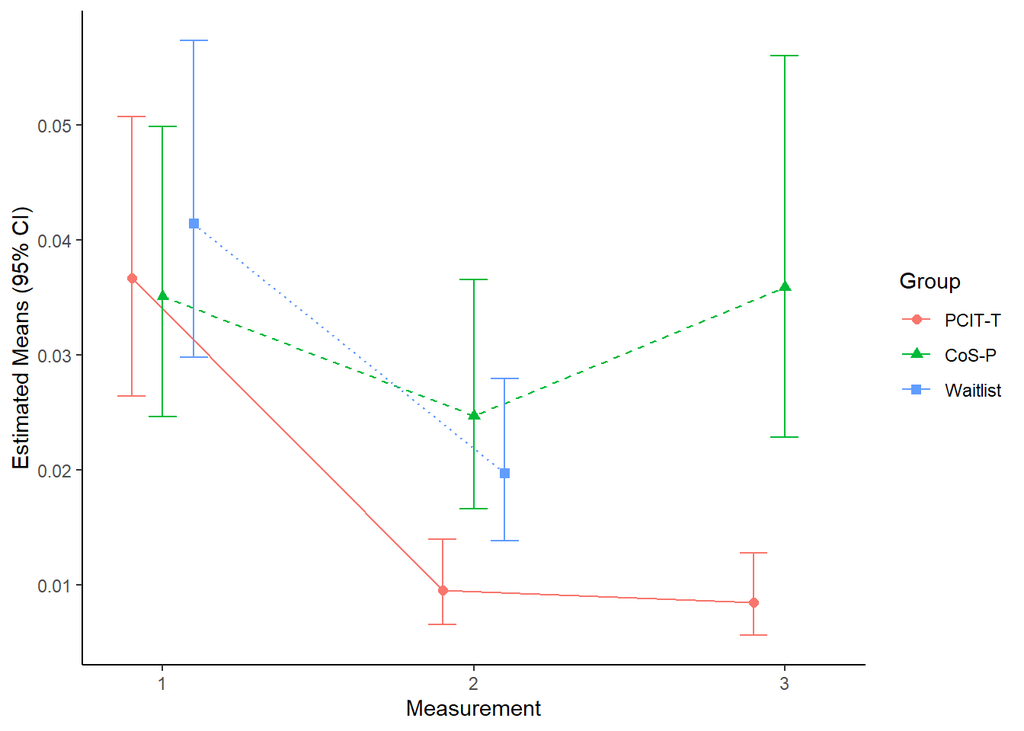

#### Hypothesis 1

We hypothesize that from baseline (‘T1’) to post-treatment/waitlist (‘T2’) there will be a gradient effect, whereby parent-child dyads who receive PCIT-T will show the greatest gains and parent-child dyads who receive no treatment will show the least gains. For the outcome, then, the null hypothesis is:

$H_0: \text {mean change}(\text{PCIT-T}) = \text {mean change}(\text{CoS-P}) = \text {mean change}(\text{Waitlist})$ $H_A: \text {mean change}(\text{PCIT-T}) > \text {mean change}(\text{CoS-P}) > \text {mean change}(\text{Waitlist})$

This is a joint hypothesis test.

First, confirming that the ordering of the means is as hypothesized:

```
## group = 1:
##  contrast odds.ratio    SE  df asymp.LCL asymp.UCL
##  1 / 2         3.954 0.456 Inf     3.017      5.18
##  1 / 3         4.473 0.646 Inf     3.188      6.28
##  2 / 3         1.131 0.191 Inf     0.761      1.68
##
## group = 2:
##  contrast odds.ratio    SE  df asymp.LCL asymp.UCL
##  1 / 2         1.436 0.159 Inf     1.109      1.86
##  1 / 3         0.977 0.160 Inf     0.665      1.44
##  2 / 3         0.680 0.115 Inf     0.458      1.01
##
## group = 3:
##  contrast odds.ratio    SE  df asymp.LCL asymp.UCL
##  1 / 2         2.150 0.178 Inf     1.772      2.61
##  1 / 3        nonEst    NA  NA        NA        NA
##  2 / 3        nonEst    NA  NA        NA        NA
##
## Results are averaged over the levels of: asdcase
## Confidence level used: 0.95
## Conf-level adjustment: tukey method for comparing a family of 3 estimates
## Intervals are back-transformed from the log odds ratio scale
```

so, change from t1 to t2 is represented as an OR. They way these results are presented, a value >1 means that there is an *decrease* from T1 to T2. So, for PCIT-T, the OR=3.954, indicating that the odds of an NTA action in the total verbalisations is much larger by a factor of 3.954 at T1 relative to T2. Alternatively, we can take the reciprocal

$\frac{1}{3.9544} = 0.25288$

and the CI limits:

$\frac{1}{5.18} = 0.1930502$

$\frac{1}{3.017} = 0.3314551$

Here, the odds of an NTA verbalisation are 0.25 times that at time 2 than time 1 for PCIT-T (odds reduced by 75%).

Now, to get the p-value associated with the joint hypothesis.

```r
## Specify contrast matrices
# Hyp1 is 1 df test
# could use alternative="less" ir alternative="greater" in glht
hyp1   <- matrix(c(0, 0, 0,0, 0,0, -1,0,0 ),1)
# Hyp2 is 1 df test,
hyp2   <- matrix(c(0, 0, 0,0, 0,1, 0,1,0 ),1)


# hypF is combined 2df test. Yes!
h<-rbind(hyp1,hyp2)
hypF <- as.matrix(h)
GlobalF <- glht(result3, linfct = hypF, test = Ftest())
GlobalF$linfct
```

```
##   (Intercept) asdcase1 group2 group3 time2 time3 group2:time2 group3:time2
## 1           0        0      0      0     0     0           -1            0
## 2           0        0      0      0     0     1            0            1
##   group2:time3
## 1            0
## 2            0
```

```r
summary(GlobalF, test = Ftest())
```

```
##
##   General Linear Hypotheses
##
## Linear Hypotheses:
##        Estimate
## 1 == 0  -1.0125
## 2 == 0  -0.8889
##
## Global Test:
##       F DF1 DF2    Pr(>F)
## 1 47.49   2 162 5.877e-17
```

```r
#also see this webpage for more on contrasts https://rcompanion.org/rcompanion/h_01.html
```

#### Hypothesis 2

There will be a gradient of size of change from T2 to T3 such that the change in the PCIT-T group > the change in the CoS-P group. This isn’t really a gradient; it’s just 1 hypothesis.

First, the change in PCITT and COSP from time 2 to time 3:

```
## group = 1:
##  time    prob      SE  df asymp.LCL asymp.UCL
##  1    0.03667 0.00612 Inf   0.02639    0.0507
##  2    0.00954 0.00186 Inf   0.00650    0.0140
##  3    0.00844 0.00178 Inf   0.00557    0.0128
##
## group = 2:
##  time    prob      SE  df asymp.LCL asymp.UCL
##  1    0.03510 0.00633 Inf   0.02460    0.0499
##  2    0.02470 0.00496 Inf   0.01663    0.0365
##  3    0.03591 0.00825 Inf   0.02282    0.0561
##
## group = 3:
##  time    prob      SE  df asymp.LCL asymp.UCL
##  1    0.04142 0.00694 Inf   0.02977    0.0574
##  2    0.01970 0.00353 Inf   0.01385    0.0280
##  3     nonEst      NA  NA        NA        NA
##
## Results are averaged over the levels of: asdcase
## Confidence level used: 0.95
## Intervals are back-transformed from the logit scale
```

```
## group = 1:
##  contrast odds.ratio    SE  df asymp.LCL asymp.UCL
##  1 / 2         3.954 0.456 Inf     3.017      5.18
##  1 / 3         4.473 0.646 Inf     3.188      6.28
##  2 / 3         1.131 0.191 Inf     0.761      1.68
##
## group = 2:
##  contrast odds.ratio    SE  df asymp.LCL asymp.UCL
##  1 / 2         1.436 0.159 Inf     1.109      1.86
##  1 / 3         0.977 0.160 Inf     0.665      1.44
##  2 / 3         0.680 0.115 Inf     0.458      1.01
##
## group = 3:
##  contrast odds.ratio    SE  df asymp.LCL asymp.UCL
##  1 / 2         2.150 0.178 Inf     1.772      2.61
##  1 / 3        nonEst    NA  NA        NA        NA
##  2 / 3        nonEst    NA  NA        NA        NA
##
## Results are averaged over the levels of: asdcase
## Confidence level used: 0.95
## Conf-level adjustment: tukey method for comparing a family of 3 estimates
## Intervals are back-transformed from the log odds ratio scale
```

```r
## Specify contrast matrices
# Hyp1 is 1 df test
# could use alternative="less" ir alternative="greater" in glht
hyp2   <- matrix(c(0, 0, 0,0, 0,0, -1,0,1 ),1)
hyp2F <- glht(result3, linfct = hyp2)
summary(hyp2F)
```

```
##
##   Simultaneous Tests for General Linear Hypotheses
##
## Fit: glmer(formula = cbind(nta, verbal - nta) ~ asdcase + group +
##     time + group * time + (1 | id), data = p, family = binomial)
##
## Linear Hypotheses:
##        Estimate Std. Error z value Pr(>|z|)
## 1 == 0   0.5089     0.2386   2.133   0.0329 *
## ---
## Signif. codes:  0 '***' 0.001 '**' 0.01 '*' 0.05 '.' 0.1 ' ' 1
## (Adjusted p values reported -- single-step method)
```

```r
#also see this webpage for more on contrasts https://rcompanion.org/rcompanion/h_01.html
```

#### Residuals

Before interpretation, we should examine model assumptions.

For this model (A generalized linear mixed model with binomial distribution and logit link, with random effect for individual), we have to use a different residual than for a linear mixed model. These are simulated residuals, using the DHARMa package in R (citation below).

Under H0 (perfect model, no violations of assumptions), we would expect a stra1ght line in the QQplot. The residuals against the fitted values should show no obvious pattern or outliers.

There are no violations of assumptions.

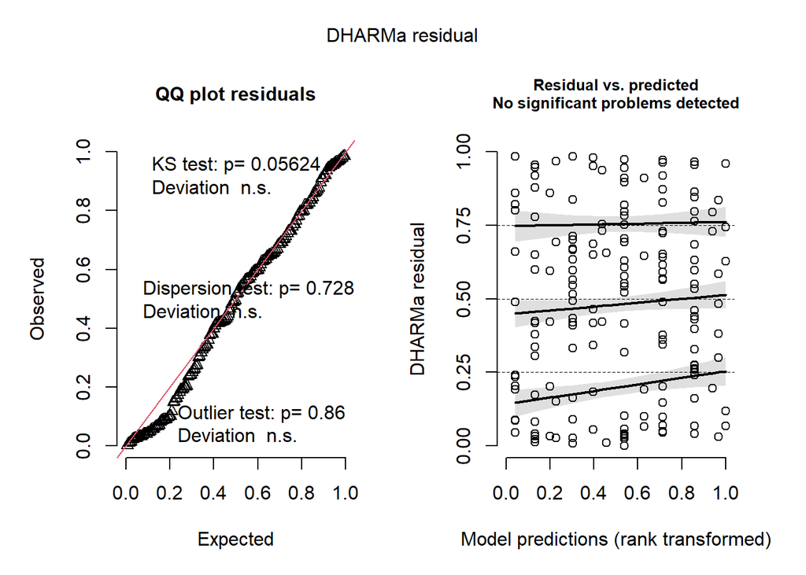

```r
library(DHARMa)

simulationOutput <- simulateResiduals(fittedModel = result3, plot = F)

plot(simulationOutput)
```

```r
citation("DHARMa")
```

```
##
##
##   Florian Hartig (2022). DHARMa: Residual Diagnostics for Hierarchical
##   (Multi-Level / Mixed) Regression Models. R package version 0.4.5.
##   https://CRAN.R-project.org/package=DHARMa
##
## A BibTeX entry for LaTeX users is
##
##   @Manual{,
##     title = {DHARMa: Residual Diagnostics for Hierarchical (Multi-Level / Mixed)
## Regression Models},
##     author = {Florian Hartig},
##     year = {2022},
##     note = {R package version 0.4.5},
##     url = {https://CRAN.R-project.org/package=DHARMa},
##   }
```

```r
rm(list = ls())
```